# Практика 3. Типы в λ-исчислении

осень 2026

Андрей Стоян, Илья Колегов

осень 2026

## Летучка 3

**Летучка 3** · 7 минут · Ваше ФИ: ____________________

1. Расставьте все скобки: $\ f\ x\ y\ z \equiv$ ______________
2. Какой $\lambda$ связывает последнее вхождение $x$ в терме $\lambda_1 x.\,\lambda_2 y.\,x\ (\lambda_3 x.\,y\ x)$? Номер: ___
3. Сделайте один β-шаг: $\ (\lambda f\,x.\,f\ (f\ x))\ \mathbf{not} \rightsquigarrow$ __________________
4. Как называются функции, принимающие функции в качестве аргументов? ____________________
5. Свойство комбинатора неподвижной точки: $\ \mathbf{Y}\ F =_\beta$ __________

## Идея систем типов

## Анализ типов: метки от листьев к корню

Программа — это дерево. Попробуем приписать каждой вершине метку-тип, двигаясь от листьев к корню.

if (x < 2) (x + 1) 0

if

<

+

0

x

2

x

1

## Анализ типов: метки от листьев к корню

Листья. Константа знает свою метку сама; про переменную $x$ нужно знать заранее — пусть $x : \mathrm{Int}$.

if (x < 2) (x + 1) 0

if

<

+

0

x

2

x

1

$: \mathrm{Int}$

$: \mathrm{Int}$

$: \mathrm{Int}$

$: \mathrm{Int}$

$: \mathrm{Int}$

## Анализ типов: метки от листьев к корню

Правило для $<$: если оба поддерева помечены $\mathrm{Int}$, вершина получает метку $\mathrm{Bool}$. Правило для $+$: оба поддерева $\mathrm{Int}$ — метка $\mathrm{Int}$.

if (x < 2) (x + 1) 0

if

<

+

0

x

2

x

1

$: \mathrm{Bool}$

$: \mathrm{Int}$

$: \mathrm{Int}$

$: \mathrm{Int}$

$: \mathrm{Int}$

$: \mathrm{Int}$

$: \mathrm{Int}$

## Анализ типов: метки от листьев к корню

Правило для if: условие помечено $\mathrm{Bool}$, ветки помечены одинаково — вершина получает метку веток. Помечено всё дерево: программа «хорошая».

if (x < 2) (x + 1) 0

if

<

+

0

x

2

x

1

$: \mathrm{Int}$

$: \mathrm{Bool}$

$: \mathrm{Int}$

$: \mathrm{Int}$

$: \mathrm{Int}$

$: \mathrm{Int}$

$: \mathrm{Int}$

$: \mathrm{Int}$

## Анализ типов: метки от листьев к корню

А если сравнить $x$ с переменной $b$, про которую дано $b : \mathrm{Bool}$? Правило для $<$ не срабатывает, метки нет, выше идти не с чем: программа отвергнута до запуска.

if (x < b) (x + 1) 0

if

<

+

0

x

b

x

1

$: \ ?$

$: \mathrm{Int}$

$: \mathrm{Int}$

$: \mathrm{Int}$

$: \mathrm{Bool}$

$: \mathrm{Int}$

$: \mathrm{Int}$

## Типы — тоже деревья

Здесь $f$ помечена $\mathrm{Int}\to\mathrm{Int}$, а вся программа — $(\mathrm{Int}\to\mathrm{Int})\to\mathrm{Int}$.

λf. f (f 1)

λf

@

f

@

f

1

$: (\mathrm{Int}\to\mathrm{Int})\to\mathrm{Int}$

$: \mathrm{Int}$

$: \mathrm{Int}\to\mathrm{Int}$

$: \mathrm{Int}$

$: \mathrm{Int}\to\mathrm{Int}$

$: \mathrm{Int}$

## Типы — тоже деревья

Стрелка — узел с двумя поддеревьями: слева тип аргумента, справа тип результата. Листья — константы $\mathrm{Int}$, $\mathrm{Bool}$ и типовые переменные $\alpha$, $\beta$.

λf. f (f 1)

λf

@

f

@

f

1

$: (\mathrm{Int}\to\mathrm{Int})\to\mathrm{Int}$

$: \mathrm{Int}$

$:$

$: \mathrm{Int}$

$:$

$: \mathrm{Int}$

→

Int

Int

→

Int

Int

## Типы — тоже деревья

Тип всей программы — тоже дерево: $(\mathrm{Int}\to\mathrm{Int})\to\mathrm{Int}$. Скобки в записи — это форма дерева: слева поддерево $\mathrm{Int}\to\mathrm{Int}$, программа принимает функцию.

λf. f (f 1)

λf

@

f

@

f

1

$:$

$: \mathrm{Int}$

$:$

$: \mathrm{Int}$

$:$

$: \mathrm{Int}$

→

Int

Int

→

Int

Int

→

→

Int

Int

Int

## Типы — тоже деревья

Остальные метки — деревья из одного листа. Итог: анализ типов аннотирует дерево программы деревьями типов; осталось договориться, по каким правилам метка вершины получается из меток поддеревьев.

λf. f (f 1)

λf

@

f

@

f

1

$:$

$:$

$:$

$:$

$:$

$:$

→

Int

Int

→

Int

Int

→

→

Int

Int

Int

Int

Int

Int

## Типы — тоже деревья

Без скобок стрелка группируется вправо: $\lambda x\,y.\,x \mathrel{\mathtt{+}} y : \mathrm{Int}\to\mathrm{Int}\to\mathrm{Int}$ — это $\mathrm{Int}\to(\mathrm{Int}\to\mathrm{Int})$, функция, возвращающая функцию. У нашей программы скобки слева — другое дерево.

λf. f (f 1)

λf

@

f

@

f

1

$:$

$:$

$:$

$:$

$:$

$:$

$\lambda x\,y.\,x \mathrel{\mathtt{+}} y :$

$\mathrm{Int}\to(\mathrm{Int}\to\mathrm{Int})$

$(\mathrm{Int}\to\mathrm{Int})\to\mathrm{Int}$

→

Int

Int

→

Int

Int

→

→

Int

Int

Int

Int

Int

Int

→

Int

→

Int

Int

## Анализ типов

- Попытаемся приписать каждой ноде программы синтаксические метки по определённым правилам
- Если метки таким образом приписать можно — программа «хорошая»
- Вид таких меток и правил задаётся *системой типов*
- Анализ типов — разновидность статического анализа: программу проверяем, не запуская

## λ<sub>→</sub> интуитивно

## Наш язык на сегодня: $\lambda_\to$ и константы

**Синтаксис $\lambda_\to$ — как в лекции** + наше расширение

- Типы: $\quad T ::= \alpha \ \mid\ T \to T$ $\ \mid\ \mathrm{Int} \ \mid\ \mathrm{Bool}$
- Термы: $\quad M ::= x \ \mid\ M\ M \ \mid\ \lambda x.\,M$ $\qquad$ по Чёрчу — $\lambda x^T.\,M$

  $\phantom{M ::=} \mid\ n \ \mid\ M \mathrel{\mathtt{+}} M \ \mid\ M \mathrel{\mathtt{-}} M \ \mid\ M \mathrel{\mathtt{*}} M$, где $n \in \mathbb{N} = \{\mathtt{0}, \mathtt{1}, \mathtt{2}, \ldots\}$

  $\phantom{M ::=} \mid\ b \ \mid\ M \mathrel{\mathtt{<}} M \ \mid\ M \mathrel{\mathtt{==}} M \ \mid\ \mathtt{if}\ M\ M\ M$, где $b \in \mathbb{B} = \{\mathtt{true}, \mathtt{false}\}$

**Расширение** — числа и були встроены в язык как новые формы терма. Это не $\mathbf{plus}$ и $\mathbf{true}$ из практики 1: раскрыть их в $\lambda$-терм нельзя; $\mathtt{2} \mathrel{\mathtt{+}} \mathtt{3} \rightsquigarrow_{+} \mathtt{5}$ происходит за один шаг

## Типизация интуитивно: конкретные типы

Припишите тип терму $\lambda x.\,x \mathrel{\mathtt{+}} \mathtt{1}$

Функция: $?\to\ ?$. Складывать можно только числа — $x : \mathrm{Int}$, сумма — число. Ответ: $\mathrm{Int}\to\mathrm{Int}$

Припишите тип терму $\lambda b.\,\mathtt{if}\ b\ \mathtt{0}\ \mathtt{1}$

$b$ — условие: $b : \mathrm{Bool}$; обе ветки $\mathrm{Int}$, значит и всё $\mathtt{if}$ — $\mathrm{Int}$. Ответ: $\mathrm{Bool}\to\mathrm{Int}$

Припишите тип терму $\mathtt{true} \mathrel{\mathtt{+}} \mathtt{1}$

Типа нет: слагаемые обязаны быть числами, а $\mathtt{true} : \mathrm{Bool}$

## Типизация интуитивно: буквы

Найдите наиболее общий тип терма $\lambda x\,y.\,x$

Типы аргументов в терме не записаны, а тело их никак не ограничивает — выбираем различные буквы: $\alpha\to\beta\to\ ?$. Результат — первый аргумент. Ответ: $\alpha\to\beta\to\alpha$

Найдите наиболее общий тип терма $\lambda x\,y\,f.\,f\ x\ y$

$f$ в теле принимает два аргумента — $x$ и $y$, на них ограничений нет: $\alpha\to\beta\to(\alpha\to\beta\to\ ?)\to\ ?$. Результат $f$ ничем не ограничен — берём свежую букву. Ответ: $\alpha\to\beta\to(\alpha\to\beta\to\gamma)\to\gamma$

## Типизация интуитивно: функции-аргументы

Припишите тип терму $\lambda x^\alpha\,f^{\alpha \to \beta}.\,f\ x$ — здесь типы аргументов уже подписаны

Видим абстракцию — пишем стрелку $\alpha\to\ ?$ и типизируем тело, зная $x^\alpha$. Тело — тоже функция: $\alpha\to((\alpha\to\beta)\to\ ?)$. Внутри знаем $x^\alpha$ и $f^{\alpha\to\beta}$: тип $x$ совпадает с типом аргумента $f$, значит $f\ x : \beta$. Ответ: $\alpha\to(\alpha\to\beta)\to\beta$

Найдите наиболее общий тип терма $\lambda f\,x.\,f\ (f\ x)$

$f$ применяют, значит $f : \alpha\to\beta$. Результат $f\ x$ снова отдают в $f$, значит $\beta$ и $\alpha$ — один тип; $x$ — того же типа. Ответ: $(\alpha\to\alpha)\to\alpha\to\alpha$

## Типизация самоприменения

А какой тип у $\lambda x.\,x\ x$?

Никакого. $x$ применяют — значит $x : \alpha\to\beta$; аргументом стоит тот же $x$ — значит $x : \alpha$. Получается $\alpha \equiv \alpha\to\beta$: тип должен быть собственной частью, а у конечного дерева так не бывает.

## Население типов интуитивно

Населите тип $(\beta\to\gamma)\to(\alpha\to\beta)\to\alpha\to\gamma$ — то есть постройте терм такого типа

- Вспоминаем про ассоциативность стрелки: $(\beta\to\gamma)\to((\alpha\to\beta)\to\alpha\to\gamma)$
- Это явно функция, пишем абстрактор: $\lambda f^{\beta\to\gamma}.\,\underbrace{\square}_{(\alpha\to\beta)\to\alpha\to\gamma}$
- Аналогично ещё две стрелки дают два аргумента: $\lambda f^{\beta\to\gamma}\,g^{\alpha\to\beta}\,x^\alpha.\,\underbrace{\square}_\gamma$
- Единственный способ получить значение типа $\gamma$ — вызвать $f$: $\quad\lambda f^{\beta\to\gamma}\,g^{\alpha\to\beta}\,x^\alpha.\,f\ \underbrace{\square}_\beta$
- Конструируем подходящий аргумент для $f$ типа $\beta$ вызовом $g$: $\quad\lambda f^{\beta\to\gamma}\,g^{\alpha\to\beta}\,x^\alpha.\,f\ (g\ \underbrace{\square}_\alpha)$
- Воспользуемся $x$, чтобы достроить терм нужного типа: $\quad\lambda f^{\beta\to\gamma}\,g^{\alpha\to\beta}\,x^\alpha.\,f\ (g\ x)$

## Буквы и константы

(а) $\lambda x.\,x : \alpha\to\alpha$. Какие из типов тоже подходят этому терму: $\ \mathrm{Int}\to\mathrm{Int}$, $\quad (\beta\to\gamma)\to(\beta\to\gamma)$, $\quad \mathrm{Int}\to\mathrm{Bool}$, $\quad \alpha\to\beta$?

(б) $\lambda x.\,x \mathrel{\mathtt{+}} \mathtt{1} : \mathrm{Int}\to\mathrm{Int}$. А тип $\alpha\to\alpha$ ему подходит?

(в) $\lambda x\,y.\,x$ имеет типы $\alpha\to\alpha\to\alpha$ и $\alpha\to\beta\to\alpha$. Который из них главнее?

- (а) Первые два. Вместо **буквы** подставляется любой тип, но один и тот же во всех её вхождениях: $\alpha\to\alpha$ — не «из любого в любой»
- (б) Нет. **Константный тип** $\mathrm{Int}$ конкретен, у него свои значения $0, 1, 2, \ldots$: букву превратить в $\mathrm{Int}$ можно, $\mathrm{Int}$ в букву — нет
- (в) Второй: первый получается из него подстановкой $\beta := \alpha$, обратно — нет. **Наиболее общий тип** — тот, из которого все остальные получаются подстановкой вместо букв

## λ<sub>→</sub> формально

## Контекст типизации

- В программах используются введённые ранее имена
- Для типизации нужно знать типы сущностей, связанных ранее с этими именами
- Будем поддерживать доп. структуру данных, которую будем заполнять именами с соответствующими им типами в процессе обхода дерева программы

**Пример на Си**

```c
int dostrange(int a, char i) {
    // point 0
    int c = 5;
    for (int i = 0; i < 15; ++i) {
        i -= 1; // point 1
        long r = i;
        i *= r; // point 2
    }
    return a + (int)i * c; // point 3
}
```

Контекст типизации в каждой из точек:

0. $a^{\mathrm{int}},\ i^{\mathrm{char}}$

1. $a^{\mathrm{int}},\ c^{\mathrm{int}},\ i^{\mathrm{int}}$

2. $a^{\mathrm{int}},\ c^{\mathrm{int}},\ i^{\mathrm{int}},\ r^{\mathrm{long}}$

3. $a^{\mathrm{int}},\ c^{\mathrm{int}},\ i^{\mathrm{char}}$

+ Глобальные определения: `<`, `+`, `*`… — это наши константы

## Контекст типизации: пример на лямбда-исчислении

В чистом лямбда-исчислении имена вводятся с помощью абстракции: $\lambda f^A\,g^B\,x^C.\,f\ (g\ x)$ по Чёрчу.

λf:A

λg:B

λx:C

@

f

@

g

x

(0)

(1)

(2)

(∗)

Контекст типизации для каждой вершины:

(0) пустой

(1) $f^A$

(2) $f^A,\ g^B$

(∗) $f^A,\ g^B,\ x^C$ — и во всех вершинах ниже

## Правила типизации $\lambda_\to$

- Δ **Синтаксис типов** $\ T ::= \alpha \ \mid\ T\to T$ — буквы и стрелка, стрелка группируется вправо; наше расширение — ещё константы $\mathrm{Int}$ и $\mathrm{Bool}$. Произвольный тип обозначаем $A, B, C$
- Δ **Утверждение типизации** $\Gamma \vdash M : A$ — «в контексте $\Gamma$ терм $M$ имеет тип $A$»
- Δ **Контекст** $\Gamma$ — объявления $x^A$ через запятую, переменные различны

Вспомните правила с лекции: по одному на каждый вид терма.

**Правила с лекции**

$\dfrac{x^A \in \Gamma}{\Gamma \vdash x : A}\ {\scriptstyle (\text{акс})}$ $\dfrac{\Gamma \vdash M : A \to B \quad \Gamma \vdash N : A}{\Gamma \vdash M\ N : B}\ {\scriptstyle (\to E)}$ $\dfrac{\Gamma,\ x^A \vdash M : B}{\Gamma \vdash \lambda x.\,M : A \to B}\ {\scriptstyle (\to I)}$

- По Чёрчу отличается только запись абстракции в $(\to I)$: $\ \lambda x^A.\,M$ вместо $\lambda x.\,M$

## Правила для констант + наше расширение

Константы — тоже вершины дерева, и у каждого вида своё правило: литералы и $\mathtt{true}$/$\mathtt{false}$ — листья, операторы и $\mathtt{if}$ — вершины с поддеревьями.

**Натуральные числа**

$\dfrac{n \in \{\mathtt{0}, \mathtt{1}, \mathtt{2}, \ldots\}}{\Gamma \vdash n : \mathrm{Int}}\ {\scriptstyle (\text{нат})}$ $\dfrac{\Gamma \vdash M : \mathrm{Int} \quad \Gamma \vdash N : \mathrm{Int}}{\Gamma \vdash M \mathrel{\mathtt{+}} N : \mathrm{Int}}\ {\scriptstyle (\mathtt{+})}$

**Були**

$\dfrac{}{\Gamma \vdash \mathtt{true} : \mathrm{Bool}}\ {\scriptstyle (\text{бул})} \qquad \dfrac{}{\Gamma \vdash \mathtt{false} : \mathrm{Bool}}\ {\scriptstyle (\text{бул})}$ $\dfrac{\Gamma \vdash M : \mathrm{Int} \quad \Gamma \vdash N : \mathrm{Int}}{\Gamma \vdash M \mathrel{\mathtt{<}} N : \mathrm{Bool}}\ {\scriptstyle (\mathtt{<})}$

$\dfrac{\Gamma \vdash C : \mathrm{Bool} \quad \Gamma \vdash M : A \quad \Gamma \vdash N : A}{\Gamma \vdash \mathtt{if}\ C\ M\ N : A}\ {\scriptstyle (\mathtt{if})}$

- Правила для $\mathtt{-}$, $\mathtt{*}$ — как $(\mathtt{+})$; для $\mathtt{==}$ — как $(\mathtt{<})$

## Проверка типа: от дерева терма к дереву вывода

Проверим догадку формально: $\ \vdash \lambda f\,x.\,f\ (f\ x) : (\alpha\to\alpha)\to\alpha\to\alpha$. Начнём с дерева терма.

$\dfrac{x^A \in \Gamma}{\Gamma \vdash x : A}\ {\scriptstyle (\text{акс})}$ $\dfrac{\Gamma \vdash M : A \to B \quad \Gamma \vdash N : A}{\Gamma \vdash M\ N : B}\ {\scriptstyle (\to E)}$ $\dfrac{\Gamma,\ x^A \vdash M : B}{\Gamma \vdash \lambda x.\,M : A \to B}\ {\scriptstyle (\to I)}$

λf

λx

@

f

@

f

x

## Проверка типа: от дерева терма к дереву вывода

Перевернём: корень внизу, листья наверху — так растут деревья вывода.

$\dfrac{x^A \in \Gamma}{\Gamma \vdash x : A}\ {\scriptstyle (\text{акс})}$ $\dfrac{\Gamma \vdash M : A \to B \quad \Gamma \vdash N : A}{\Gamma \vdash M\ N : B}\ {\scriptstyle (\to E)}$ $\dfrac{\Gamma,\ x^A \vdash M : B}{\Gamma \vdash \lambda x.\,M : A \to B}\ {\scriptstyle (\to I)}$

λf

λx

@

f

@

f

x

## Проверка типа: от дерева терма к дереву вывода

Подпишем в каждой вершине её подтерм целиком: именно про него будет говорить утверждение типизации в этой вершине.

$\dfrac{x^A \in \Gamma}{\Gamma \vdash x : A}\ {\scriptstyle (\text{акс})}$ $\dfrac{\Gamma \vdash M : A \to B \quad \Gamma \vdash N : A}{\Gamma \vdash M\ N : B}\ {\scriptstyle (\to E)}$ $\dfrac{\Gamma,\ x^A \vdash M : B}{\Gamma \vdash \lambda x.\,M : A \to B}\ {\scriptstyle (\to I)}$

λf x. f (f x)

λx. f (f x)

f (f x)

f

f x

f

x

## Проверка типа: от дерева терма к дереву вывода

Применяем правила снизу вверх. Выбора нет: вид подтерма — абстракция, аппликация или переменная — сам называет правило. Здесь $\Gamma \equiv f^{\alpha\to\alpha},\ x^\alpha$.

$\dfrac{x^A \in \Gamma}{\Gamma \vdash x : A}\ {\scriptstyle (\text{акс})}$ $\dfrac{\Gamma \vdash M : A \to B \quad \Gamma \vdash N : A}{\Gamma \vdash M\ N : B}\ {\scriptstyle (\to E)}$ $\dfrac{\Gamma,\ x^A \vdash M : B}{\Gamma \vdash \lambda x.\,M : A \to B}\ {\scriptstyle (\to I)}$

$\Gamma \vdash f : \alpha\to\alpha$ (акс)

$\Gamma \vdash f : \alpha\to\alpha$ (акс)

$\Gamma \vdash x : \alpha$ (акс)

$\Gamma \vdash f\ x : \alpha$ (→E)

$f^{\alpha\to\alpha},\ x^\alpha \vdash f\ (f\ x) : \alpha$ (→E)

$f^{\alpha\to\alpha} \vdash \lambda x.\,f\ (f\ x) : \alpha\to\alpha$ (→I)

$\vdash \lambda f\,x.\,f\ (f\ x) : (\alpha\to\alpha)\to\alpha\to\alpha$ (→I)

шаги

1. λf — абстракция: (→I), $f^{\alpha\to\alpha}$ уходит в контекст

2. λx — абстракция: (→I), в контекст уходит $x^\alpha$

3. f (f x) — аппликация: (→E), две ветки

4. f — переменная: (акс), $f^{\alpha\to\alpha} \in \Gamma$

5. f x — аппликация: (→E), снова две ветки

6. f — переменная: (акс)

7. x — переменная: (акс), $x^\alpha \in \Gamma$ — все листья закрыты

Утверждение проверено: дерево вывода — это перевёрнутое дерево терма, в котором каждая вершина снабжена контекстом и типом.

## Дерево вывода с дырками

Заполните пронумерованные пропуски — типы и названия правил — в дереве вывода для

$\ \vdash \lambda x.\,\mathtt{if}\ (x \mathrel{\mathtt{<}} \mathtt{2})\ (x \mathrel{\mathtt{+}} \mathtt{1})\ \mathtt{0} : \mathrm{Int}\to\mathrm{Int}$.

$$\dfrac{
\dfrac{
\dfrac{
\dfrac{}{\Gamma \vdash x : \square_5}\ {\scriptstyle (\text{акс})}
\quad
\dfrac{}{\Gamma \vdash \mathtt{2} : \mathrm{Int}}\ {\scriptstyle \square_4}
}{\Gamma \vdash x \mathrel{\mathtt{<}} \mathtt{2} : \square_3}\ {\scriptstyle (\mathtt{<})}
\qquad
\dfrac{
\dfrac{}{\Gamma \vdash x : \mathrm{Int}}\ {\scriptstyle \square_7}
\quad
\dfrac{}{\Gamma \vdash \mathtt{1} : \mathrm{Int}}\ {\scriptstyle (\text{нат})}
}{\Gamma \vdash x \mathrel{\mathtt{+}} \mathtt{1} : \mathrm{Int}}\ {\scriptstyle \square_6}
\qquad
\dfrac{}{\Gamma \vdash \mathtt{0} : \square_8}\ {\scriptstyle (\text{нат})}
}{x^{\square_1} \vdash \mathtt{if}\ (x \mathrel{\mathtt{<}} \mathtt{2})\ (x \mathrel{\mathtt{+}} \mathtt{1})\ \mathtt{0} : \mathrm{Int}}\ {\scriptstyle \square_2}
}{\vdash \lambda x.\,\mathtt{if}\ (x \mathrel{\mathtt{<}} \mathtt{2})\ (x \mathrel{\mathtt{+}} \mathtt{1})\ \mathtt{0} : \mathrm{Int}\to\mathrm{Int}}\ {\scriptstyle (\to I)}$$

Здесь $\Gamma \equiv x^{\mathrm{Int}}$.

$\square_1 = \mathrm{Int}$ (контекст после $(\to I)$); $\ \square_2 = (\mathtt{if})$; $\ \square_3 = \mathrm{Bool}$; $\ \square_4 = (\text{нат})$; $\ \square_5 = \mathrm{Int}$; $\ \square_6 = (\mathtt{+})$; $\ \square_7 = (\text{акс})$; $\ \square_8 = \mathrm{Int}$ — ветки $\mathtt{if}$ одного типа.

## Дерево вывода с нуля

Постройте дерево вывода для $\ \vdash \lambda x\,f.\,f\ x : \alpha\to(\alpha\to\beta)\to\beta$

Пусть $\Gamma \equiv x^\alpha,\ f^{\alpha\to\beta}$.

$$\dfrac{
\dfrac{
\dfrac{
\dfrac{}{\Gamma \vdash f : \alpha\to\beta}\ {\scriptstyle (\text{акс})}
\quad
\dfrac{}{\Gamma \vdash x : \alpha}\ {\scriptstyle (\text{акс})}
}{x^\alpha,\ f^{\alpha\to\beta} \vdash f\ x : \beta}\ {\scriptstyle (\to E)}
}{x^\alpha \vdash \lambda f.\,f\ x : (\alpha\to\beta)\to\beta}\ {\scriptstyle (\to I)}
}{\vdash \lambda x\,f.\,f\ x : \alpha\to(\alpha\to\beta)\to\beta}\ {\scriptstyle (\to I)}$$

## Верно ли утверждение?

Поднимите руку, если утверждение выводимо:

(а) $\ \vdash \mathbf{K} : \alpha\to\alpha\to\alpha$

(б) $\ \vdash \mathbf{K} : \alpha\to\alpha\to\beta$

(в) $\ a^{\alpha\to\alpha} \vdash \mathbf{I}\ a : \alpha\to\alpha$

(г) $\ a^{\alpha\to\alpha} \vdash a\ b : \alpha$

(д) $\ \vdash \lambda x.\,x : \mathrm{Int}\to\mathrm{Int}$

(е) $\ \vdash \lambda x.\,x \mathrel{\mathtt{+}} \mathtt{1} : \alpha\to\alpha$

Выводимы (а), (в), (д). В (а) тип не наиболее общий, но дерево строится. В (б) результат — первый аргумент, он типа $\alpha$. В (г) переменной $b$ нет в контексте. (д) и (е) — снова буквы против констант: вместо буквы $\mathrm{Int}$ подставить можно, а сделать из $\mathrm{Int}$ букву — нет.

## Простые примеры задач населения

Найдите все термы $M$: $\ x^\beta \vdash M : \alpha \to \alpha$

Найдите все термы $M$: $\ x^\beta \vdash M : \alpha \to \beta$

Найдите все термы $M$: $\ x^\beta \vdash M : \alpha \to \gamma$

- Единственный терм типа $\alpha$ передаётся аргументом — обязаны его вернуть: $M \equiv \lambda y.\,y$
- Единственное значение типа $\beta$ есть в контексте — обязаны вернуть его: $M \equiv \lambda y.\,x$
- Значение типа $\gamma$ брать неоткуда: этот тип не населён в данном контексте

## Сколько обитателей у типа?

Сколько замкнутых термов в нормальной форме у каждого типа?

(а) $\alpha\to\alpha\to\alpha$

(б) $(\alpha\to\alpha)\to\alpha\to\alpha$

(в) $\alpha$

(г) $\mathrm{Int}$

- (а) Два: $\lambda x\,y.\,x$ и $\lambda x\,y.\,y$ — больше взять значение типа $\alpha$ неоткуда
- (б) Бесконечно много: $\lambda s\,z.\,z$, $\ \lambda s\,z.\,s\ z$, $\ \lambda s\,z.\,s\ (s\ z)$, … — это числа Чёрча!
- (в) Ни одного: у буквы нет своих значений, а аргументов, из которых её можно взять, нет
- (г) Бесконечно много: $0, 1, 2, \ldots$ — у константного типа значения свои

## Рекурсия возвращается: `fix` факультативно

- $\mathbf{Y} := \lambda f.\,(\lambda x.\,f\ (x\ x))\ (\lambda x.\,f\ (x\ x))$ содержит $x\ x$ — в $\lambda_\to$ у него нет типа, как и у любого другого комбинатора неподвижной точки: все программы $\lambda_\to$ завершаются
- Значит, рекурсию встраиваем в язык так же, как числа и були: новая форма терма $\mathtt{fix}\ M$, от которой нужно ровно свойство $\mathbf{Y}$ из П2 — $\mathtt{fix}\ M =_\beta M\ (\mathtt{fix}\ M)$

Задайте $\mathtt{fix}$ полностью: (а) строку в грамматике термов; (б) правило типизации; (в) правило редукции.

(а) $\ M ::= \ldots \ \mid\ \mathtt{fix}\ M \qquad$ (б) $\ \dfrac{\Gamma \vdash M : A \to A}{\Gamma \vdash \mathtt{fix}\ M : A}\ {\scriptstyle (\mathtt{fix})}\qquad$ (в) $\ \mathtt{fix}\ M \rightsquigarrow M\ (\mathtt{fix}\ M)$

Аргумент $\mathtt{fix}$ — функция от «самой себя»: тип $A \to A$; результат — неподвижная точка, тип $A$.

## Факториал в расширенном языке факультативно

$$\mathbf{fac} := \mathtt{fix}\ F, \qquad F \equiv \lambda f\,n.\,\mathtt{if}\ (n \mathrel{\mathtt{==}} \mathtt{0})\ \mathtt{1}\ (n \mathrel{\mathtt{*}} f\ (n \mathrel{\mathtt{-}} \mathtt{1}))$$

- Как в П2: рекурсивный вызов абстрагирован по имени $f$ — только вместо $\mathbf{Y}$ стоит $\mathtt{fix}$, а вместо кодировок — константы

Какой тип у $F$? У $\mathbf{fac}$?

$F : (\mathrm{Int}\to\mathrm{Int})\to\mathrm{Int}\to\mathrm{Int}$ — принимает «себя» и число; по правилу $(\mathtt{fix})$ с $A := \mathrm{Int}\to\mathrm{Int}$ получаем $\mathbf{fac} : \mathrm{Int}\to\mathrm{Int}$.

## Дерево типизации факториала факультативно

$F \equiv \lambda f\,n.\,\mathtt{if}\ (n \mathrel{\mathtt{==}} \mathtt{0})\ \mathtt{1}\ (n \mathrel{\mathtt{*}} f\ (n \mathrel{\mathtt{-}} \mathtt{1}))$, $\quad \Gamma \equiv f^{\mathrm{Int}\to\mathrm{Int}},\ n^{\mathrm{Int}}$

$\Gamma \vdash n : \mathrm{Int}$ (акс)

$\Gamma \vdash \mathtt{0} : \mathrm{Int}$ (нат)

$\Gamma \vdash n \mathrel{\mathtt{==}} \mathtt{0} : \mathrm{Bool}$ (==)

$\Gamma \vdash \mathtt{1} : \mathrm{Int}$ (нат)

$\Gamma \vdash n : \mathrm{Int}$ (акс)

$\Gamma \vdash f : \mathrm{Int}\to\mathrm{Int}$ (акс)

$\Gamma \vdash n : \mathrm{Int}$ (акс)

$\Gamma \vdash \mathtt{1} : \mathrm{Int}$ (нат)

$\Gamma \vdash n \mathrel{\mathtt{-}} \mathtt{1} : \mathrm{Int}$ (−)

$\Gamma \vdash f\ (n \mathrel{\mathtt{-}} \mathtt{1}) : \mathrm{Int}$ (→E)

$\Gamma \vdash n \mathrel{\mathtt{*}} f\ (n \mathrel{\mathtt{-}} \mathtt{1}) : \mathrm{Int}$ (∗)

$\Gamma \vdash \mathtt{if}\ (n \mathrel{\mathtt{==}} \mathtt{0})\ \mathtt{1}\ (n \mathrel{\mathtt{*}} f\ (n \mathrel{\mathtt{-}} \mathtt{1})) : \mathrm{Int}$ (if)

$f^{\mathrm{Int}\to\mathrm{Int}} \vdash \lambda n.\,\mathtt{if}\ \ldots : \mathrm{Int}\to\mathrm{Int}$ (→I)

$\vdash F : (\mathrm{Int}\to\mathrm{Int})\to\mathrm{Int}\to\mathrm{Int}$ (→I)

$\vdash \mathtt{fix}\ F : \mathrm{Int}\to\mathrm{Int}$ (fix)

## Как работает fix: fac 2 факультативно

Раскрыли $\mathbf{fac}$; дальше единственное правило для $\mathtt{fix}$ — редукция $\mathtt{fix}\ M \rightsquigarrow M\ (\mathtt{fix}\ M)$.

fix F 2

цепочка

$\mathbf{fac}\ \mathtt{2} \rightsquigarrow_{\mathbf{fac}} \mathtt{fix}\ F\ \mathtt{2}$

## Как работает fix: fac 2 факультативно

Правило $(\mathtt{fix})$: наружу вышла копия $F$, внутри остался $\mathtt{fix}\ F$ — запас на следующий виток.

F (fix F) 2

цепочка

$\mathbf{fac}\ \mathtt{2} \rightsquigarrow_{\mathbf{fac}} \mathtt{fix}\ F\ \mathtt{2}$

$\rightsquigarrow_{\mathtt{fix}}\ F\ (\mathtt{fix}\ F)\ \mathtt{2}$

## Как работает fix: fac 2 факультативно

Два β-шага: $f$ стало $\mathtt{fix}\ F$, $n$ стало $\mathtt{2}$. Перед нами тело $F$ — обычный $\mathtt{if}$ с константами.

if (2 == 0) 1 (2 * fix F (2 − 1))

цепочка

$\mathbf{fac}\ \mathtt{2} \rightsquigarrow_{\mathbf{fac}} \mathtt{fix}\ F\ \mathtt{2}$

$\rightsquigarrow_{\mathtt{fix}}\ F\ (\mathtt{fix}\ F)\ \mathtt{2}$

$\twoheadrightarrow_\beta\ \mathtt{if}\ (\mathtt{2} \mathrel{\mathtt{==}} \mathtt{0})\ \mathtt{1}\ (\mathtt{2} \mathrel{\mathtt{*}} \mathtt{fix}\ F\ (\mathtt{2} \mathrel{\mathtt{-}} \mathtt{1}))$

## Как работает fix: fac 2 факультативно

Константы считаются за шаг: $\mathtt{2} \mathrel{\mathtt{==}} \mathtt{0} \rightsquigarrow \mathtt{false}$, $\mathtt{if}$ выбрал ветку else, $\mathtt{2} \mathrel{\mathtt{-}} \mathtt{1} \rightsquigarrow \mathtt{1}$. Снаружи остался $\mathtt{2} \mathrel{\mathtt{*}}$, внутри — тот же кадр, что в начале.

2 * fix F 1

цепочка

$\mathbf{fac}\ \mathtt{2} \rightsquigarrow_{\mathbf{fac}} \mathtt{fix}\ F\ \mathtt{2}$

$\rightsquigarrow_{\mathtt{fix}}\ F\ (\mathtt{fix}\ F)\ \mathtt{2}$

$\twoheadrightarrow_\beta\ \mathtt{if}\ (\mathtt{2} \mathrel{\mathtt{==}} \mathtt{0})\ \mathtt{1}\ (\mathtt{2} \mathrel{\mathtt{*}} \mathtt{fix}\ F\ (\mathtt{2} \mathrel{\mathtt{-}} \mathtt{1}))$

$\twoheadrightarrow\ \mathtt{2} \mathrel{\mathtt{*}} \mathtt{fix}\ F\ \mathtt{1}$ — правила $(\mathtt{==})$, $(\mathtt{if})$, $(\mathtt{-})$

## Как работает fix: fac 2 факультативно

Второй виток: снова $(\mathtt{fix})$, β-шаги и условие; снаружи ещё один множитель.

2 * 1 * fix F 0

цепочка

$\mathbf{fac}\ \mathtt{2} \rightsquigarrow_{\mathbf{fac}} \mathtt{fix}\ F\ \mathtt{2}$

$\rightsquigarrow_{\mathtt{fix}}\ F\ (\mathtt{fix}\ F)\ \mathtt{2}$

$\twoheadrightarrow_\beta\ \mathtt{if}\ (\mathtt{2} \mathrel{\mathtt{==}} \mathtt{0})\ \mathtt{1}\ (\mathtt{2} \mathrel{\mathtt{*}} \mathtt{fix}\ F\ (\mathtt{2} \mathrel{\mathtt{-}} \mathtt{1}))$

$\twoheadrightarrow\ \mathtt{2} \mathrel{\mathtt{*}} \mathtt{fix}\ F\ \mathtt{1}$ — правила $(\mathtt{==})$, $(\mathtt{if})$, $(\mathtt{-})$

$\twoheadrightarrow\ \mathtt{2} \mathrel{\mathtt{*}} \mathtt{1} \mathrel{\mathtt{*}} \mathtt{fix}\ F\ \mathtt{0}$ — виток 2

## Как работает fix: fac 2 факультативно

Третий виток: копия, β-шаги — и на этот раз $\mathtt{0} \mathrel{\mathtt{==}} \mathtt{0}$ истинно.

2 * 1 * if (0 == 0) 1 (0 * fix F (0 − 1))

цепочка

$\mathbf{fac}\ \mathtt{2} \rightsquigarrow_{\mathbf{fac}} \mathtt{fix}\ F\ \mathtt{2}$

$\rightsquigarrow_{\mathtt{fix}}\ F\ (\mathtt{fix}\ F)\ \mathtt{2}$

$\twoheadrightarrow_\beta\ \mathtt{if}\ (\mathtt{2} \mathrel{\mathtt{==}} \mathtt{0})\ \mathtt{1}\ (\mathtt{2} \mathrel{\mathtt{*}} \mathtt{fix}\ F\ (\mathtt{2} \mathrel{\mathtt{-}} \mathtt{1}))$

$\twoheadrightarrow\ \mathtt{2} \mathrel{\mathtt{*}} \mathtt{fix}\ F\ \mathtt{1}$ — правила $(\mathtt{==})$, $(\mathtt{if})$, $(\mathtt{-})$

$\twoheadrightarrow\ \mathtt{2} \mathrel{\mathtt{*}} \mathtt{1} \mathrel{\mathtt{*}} \mathtt{fix}\ F\ \mathtt{0}$ — виток 2

$\twoheadrightarrow\ \mathtt{2} \mathrel{\mathtt{*}} \mathtt{1} \mathrel{\mathtt{*}} \mathtt{if}\ (\mathtt{0} \mathrel{\mathtt{==}} \mathtt{0})\ \mathtt{1}\ (\mathtt{0} \mathrel{\mathtt{*}} \mathtt{fix}\ F\ (\mathtt{0} \mathrel{\mathtt{-}} \mathtt{1}))$ — виток 3

## Как работает fix: fac 2 факультативно

$\mathtt{if}$ вернул $\mathtt{1}$, ветка с $\mathtt{fix}\ F\ (\mathtt{0} \mathrel{\mathtt{-}} \mathtt{1})$ выброшена, так и не раскрывшись: $\mathtt{fix}$ разворачивался ровно столько раз, сколько потребовало условие.

2 * 1 * 1 ↠ 2

цепочка

$\mathbf{fac}\ \mathtt{2} \rightsquigarrow_{\mathbf{fac}} \mathtt{fix}\ F\ \mathtt{2}$

$\rightsquigarrow_{\mathtt{fix}}\ F\ (\mathtt{fix}\ F)\ \mathtt{2}$

$\twoheadrightarrow_\beta\ \mathtt{if}\ (\mathtt{2} \mathrel{\mathtt{==}} \mathtt{0})\ \mathtt{1}\ (\mathtt{2} \mathrel{\mathtt{*}} \mathtt{fix}\ F\ (\mathtt{2} \mathrel{\mathtt{-}} \mathtt{1}))$

$\twoheadrightarrow\ \mathtt{2} \mathrel{\mathtt{*}} \mathtt{fix}\ F\ \mathtt{1}$ — правила $(\mathtt{==})$, $(\mathtt{if})$, $(\mathtt{-})$

$\twoheadrightarrow\ \mathtt{2} \mathrel{\mathtt{*}} \mathtt{1} \mathrel{\mathtt{*}} \mathtt{fix}\ F\ \mathtt{0}$ — виток 2

$\twoheadrightarrow\ \mathtt{2} \mathrel{\mathtt{*}} \mathtt{1} \mathrel{\mathtt{*}} \mathtt{if}\ (\mathtt{0} \mathrel{\mathtt{==}} \mathtt{0})\ \mathtt{1}\ (\mathtt{0} \mathrel{\mathtt{*}} \mathtt{fix}\ F\ (\mathtt{0} \mathrel{\mathtt{-}} \mathtt{1}))$ — виток 3

$\twoheadrightarrow\ \mathtt{2} \mathrel{\mathtt{*}} \mathtt{1} \mathrel{\mathtt{*}} \mathtt{1} \twoheadrightarrow \mathtt{2}$ — правила $(\mathtt{==})$, $(\mathtt{if})$, $(\mathtt{*})$

## Сегодня мы многое поняли

- Анализ типов — по правилам расставляем метки — просто!
- Научили мозг проверке типов — отличать хорошие программы от плохих
- Объяснить по всей строгости, почему программа типизируется или нет

## Таинственные связи ☁

Дерево вывода типа комбинатора $\mathbf{B}$ для произвольных типов $A, B, C$ — или вывод силлогизма в исчислении высказываний?

$$\dfrac{
\dfrac{
\dfrac{
\dfrac{
\dfrac{}{\Gamma \vdash {\color{blue}f :}\ B\to C}\ {\scriptstyle (\text{акс})}
\qquad
\dfrac{
\dfrac{}{\Gamma \vdash {\color{blue}g :}\ A\to B}\ {\scriptstyle (\text{акс})}
\quad
\dfrac{}{\Gamma \vdash {\color{blue}x :}\ A}\ {\scriptstyle (\text{акс})}
}{\Gamma \vdash {\color{blue}g\ x :}\ B}\ {\scriptstyle (\to E)}
}{{\color{blue}f}^{B\to C},\ {\color{blue}g}^{A\to B},\ {\color{blue}x}^{A} \vdash {\color{blue}f\ (g\ x) :}\ C}\ {\scriptstyle (\to E)}
}{{\color{blue}f}^{B\to C},\ {\color{blue}g}^{A\to B} \vdash {\color{blue}\lambda x.\,f\ (g\ x) :}\ A\to C}\ {\scriptstyle (\to I)}
}{{\color{blue}f}^{B\to C} \vdash {\color{blue}\lambda g\,x.\,f\ (g\ x) :}\ (A\to B)\to A\to C}\ {\scriptstyle (\to I)}
}{\vdash {\color{blue}\lambda f\,g\,x.\,f\ (g\ x) :}\ (B\to C)\to(A\to B)\to A\to C}\ {\scriptstyle (\to I)}$$

## Таинственные связи ☁

Дерево вывода типа комбинатора $\mathbf{B}$ для произвольных типов $A, B, C$ — или вывод силлогизма в исчислении высказываний?

$$\dfrac{
\dfrac{
\dfrac{
\dfrac{
\dfrac{}{\Gamma \vdash \phantom{f :}\ B\to C}\ {\scriptstyle (\text{акс})}
\qquad
\dfrac{
\dfrac{}{\Gamma \vdash \phantom{g :}\ A\to B}\ {\scriptstyle (\text{акс})}
\quad
\dfrac{}{\Gamma \vdash \phantom{x :}\ A}\ {\scriptstyle (\text{акс})}
}{\Gamma \vdash \phantom{g\ x :}\ B}\ {\scriptstyle (\to E)}
}{{\phantom{f}}^{B\to C},\ {\phantom{g}}^{A\to B},\ {\phantom{x}}^{A} \vdash \phantom{f\ (g\ x) :}\ C}\ {\scriptstyle (\to E)}
}{{\phantom{f}}^{B\to C},\ {\phantom{g}}^{A\to B} \vdash \phantom{\lambda x.\,f\ (g\ x) :}\ A\to C}\ {\scriptstyle (\to I)}
}{{\phantom{f}}^{B\to C} \vdash \phantom{\lambda g\,x.\,f\ (g\ x) :}\ (A\to B)\to A\to C}\ {\scriptstyle (\to I)}
}{\vdash \phantom{\lambda f\,g\,x.\,f\ (g\ x) :}\ (B\to C)\to(A\to B)\to A\to C}\ {\scriptstyle (\to I)}$$

## Материалы ☁

## Типизация в стиле Карри и в стиле Чёрча

|  | по Карри | по Чёрчу |
| --- | --- | --- |
| **абстракция** | $\lambda x.\,M$ | $\lambda x^A.\,M$ — в домашке `\x:a. x` |
| **количество кода** | меньше кода, сложнее задача типовой подсистеме языка | программисту приходится больше писать |
| **сколько типов у терма** | либо $0$, либо $\infty$ | либо $0$, либо $1$ |
| **алгоритм** | сложнее: приходится решать систему типовых уравнений (П13) | проще: вся необходимая информация написана в терме |
| **в вашем языке** | Haskell, OCaml; `auto` в C++, `var` в Java и C# | типы параметров в C, Java, Go |

## Мотивация статического анализа программ

- Программное обеспечение — это сложно
- В программах случаются ошибки (постоянно и неизбежно)
- Поиск ошибок может занимать годы, десятилетия, вечность
- Нужны методы для того, чтобы судить о программах и их свойствах автоматически
- Программы могут работать долго
- Хотим отвергать «плохие» программы до исполнения (статически)

## Роль типов в языках

- Позволяют выявлять некоторые классы ошибок:

  ```haskell
  GHCi> length 42         -- Ошибка: на вход не список, а число
  GHCi> foldr (+) "ABCDE" -- Ошибка: плюс работает на числах, но не символах
  ```

- Механизм абстракции: интерфейс, скрывающий детали реализации
- Средство документирования: как использовать сущность
- *Частичная* спецификация поведения
- Позволяют генерировать более эффективный низкоуровневый код

## Ограниченность систем типов ☁

- Хотелось бы, чтобы все «хорошие» программы типизировались, а все «плохие» — нет
- Однако по теореме Успенского-Райса задача проверки любого нетривиального<sup>1</sup> свойства программы неразрешима

В чем подвох с системами типов?

- Всё, что типизируется, — «хорошее», но обратное не всегда верно
- ⇒ Всегда существуют «хорошие» программы, которые не типизируются<sup>2</sup>

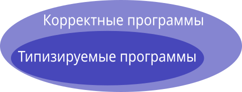

[^1]: Существуют программы, как обладающие таким свойством, так и не обладающие.
[^2]: На практике к тому же зачастую существуют «плохие», которые типизируются.

## Деревья вывода

- Теория доказательств математической логики — доказываем принадлежность утверждения типизации множеству истинных утверждений
- Истинное утверждение в теории доказательств — то, которое можно *синтаксически* вывести по правилам вывода из аксиом
- Деревья вывода — синтаксические, машинно-проверяемые конструкции
- Деревья сами по себе не несут смысла, наличие корректного дерева говорит только о возможности его построения
- Чтобы деревья имели смысл, для каждой теории доказываются утверждения вида:
  - Если существует дерево вывода с корнем X, то верно Y
  - e.g. Если существует $\lambda_\to$ дерево с утверждением про терм $M$ в корне (терм $M$ в таком-то контексте имеет такой-то тип), то этот терм строго нормализуем
- Иногда по правилам вывода очевиден алгоритм построения дерева
  - В нашем случае (для $\lambda_\to$) это так
  - В общем случае — нет (математики оказались бы не нужны)

## Не всё сильно-нормализуемое типизируется ✱

Вспомним: всё, что типизируется, «хорошее», но обратное не всегда верно. Будем «хорошим» считать сильную нормализуемость.

$\mathbf{2}\ \mathbf{K}$ терм сильно нормализуем и редуцируется так:

$$\mathbf{2}\ \mathbf{K} = \lambda z.\,\mathbf{K}\ (\mathbf{K}\ z) = \lambda z\,a\,b.\,z$$

Однако протипизировать это не получится.

- Наиболее общий тип $\mathbf{K}$ — это $\gamma \to \tau \to \gamma$
- $\mathbf{2} := \lambda s\,z.\,s\ (s\ z)$, наиболее общий тип $\mathbf{2}$ — это $(\alpha \to \alpha) \to \alpha \to \alpha$
- По правилу типизации аппликации, применение $\mathbf{2}$ к $\mathbf{K}$ накладывает на $\gamma, \tau, \alpha$ ограничения $\alpha = \gamma,\ \alpha = \tau \to \gamma$

Противоречие.

## Эквивалентности не сохраняют тип ✱

**$\beta$-эквивалентность не сохраняет тип**

Из лекции известно, что если $M$ редуцируется к $N$ и $\Gamma \vdash M : \tau$, то $\Gamma \vdash N : \tau$.

Неправда, что если $M$ редуцируется к $N$ и $\Gamma \vdash N : \tau$, то $\Gamma \vdash M : \tau$.

Пример: $N = \lambda x.\,x$, $N : \alpha \to \alpha$; $M = \lambda x.\,(\lambda y.\,x)\ (x\ \mathbf{I})$, и за одно редуцирование $M$ переходит в $N$, но $M : \alpha \to \alpha$ не выполняется: тогда бы подтерм $x\ \mathbf{I}$ не типизировался, так как $\alpha$ не является стрелочным типом.

**$\eta$-эквивалентность не сохраняет тип**

Если $\lambda x.\,M\ x : \tau$ (где $x$ не является свободным в $M$), то $M : \tau$.

Если $M : \tau$, то не обязательно $\lambda x.\,M\ x : \tau$.

Пример: $\mathbf{I} : \alpha \to \alpha$, но $\lambda x\,y.\,x\ y : (\beta \to \gamma) \to (\beta \to \gamma)$ нельзя приписать тип $\alpha \to \alpha$: тогда бы подтерм $x\ y$ не типизировался, так как $\alpha$ не является стрелочным типом.

## Что посмотреть в транспорте

- [Формальная верификация операционных систем](https://youtu.be/f12hIDF0XPc)

## Серьёзные материалы

- [Соответствие Карри–Говарда: от матлогики к программированию](https://www.mccme.ru/dubna/2017/courses/bragilevsky.html)
- [Вывод типов от Хиндли-Милнера до GHC 8.8](https://www.youtube.com/watch?v=_HYI7zjkrEs&list=PLvPsfYrGz3wuVAGhNf6-i7uafXg56oqM5)
- [Программирование с зависимыми типами на языке Idris](https://youtu.be/o-7zhrUP3ds)
- [Edwin Brady «Type-Driven Development with Idris»](https://www.amazon.com/Type-driven-Development-Idris-Edwin-Brady/dp/1617293024)
- Pierce, Benjamin C. Types and programming languages. MIT press, 2002.
- Пирс Б. Типы в языках программирования. — Лямбда пресс, Добросвет, 2012. — 656 c.
- [Sandy Maguire «Thinking with Types. Type-Level Programming in Haskell»](https://thinkingwithtypes.com/)
- Henk Barendregt, Wil Dekkers, and Richard Statman. «Lambda Calculus with Types». Cambridge University Press, New York, NY, USA, 2013.
- Dunfield, Jana, and Neel Krishnaswami. «Bidirectional typing.» *ACM Computing Surveys (CSUR)* 54.5 (2021): 1-38.